# Primates_modeling

Gene Estrada

2023-05-16

Here is the original continuous model (brms3 in the CSCAR rmd file)

```r
brms3 <- brm(ground.use.prop ~
                 Estrada.Continent +                           #continent
                 AvBody.mass.comb.sc +                         #body mass
                 Perc.fruit.comb.sc +                          #percent fruit in diet
                 WC1_area_mean.sc +                            #max temperature (mean across range)
                 WC12_area_mean.sc +                           #rainfall
                 FH.Median.sc +                                #forest height
                 TC.median.sc +                                #canopy cover percentage
               (1|gr(TenK.tax, cov = A)),
               family = zero_inflated_beta(link = "logit"),
               data = primates,
               data2 = list(A = A),
               iter = 6000, warmup = 2000, thin = 1,
               prior = c(prior(normal(0,10), class = "Intercept"),
                         prior(normal(0,1), class = "b")),
               control = list(adapt_delta = 0.9999),
               cores = 10)
#model summary
summary(brms3)
```

```
##  Family: zero_inflated_beta
##   Links: mu = logit; phi = identity; zi = identity
## Formula: ground.use.prop ~ Estrada.Continent + AvBody.mass.comb.sc + Perc.fruit.comb.sc + WC1_area_mean.sc + WC12_area_mean.sc + FH.Median.sc + TC.median.sc + (1 | gr(TenK.tax, cov = A))
##    Data: primates (Number of observations: 132)
##   Draws: 4 chains, each with iter = 6000; warmup = 2000; thin = 1;
##          total post-warmup draws = 16000
##
## Group-Level Effects:
## ~TenK.tax (Number of levels: 132)
##               Estimate Est.Error l-95% CI u-95% CI Rhat Bulk_ESS Tail_ESS
## sd(Intercept)     0.24      0.18     0.08     0.72 1.16       18       21
##
## Population-Level Effects:
##                             Estimate Est.Error l-95% CI u-95% CI Rhat Bulk_ESS
## Intercept                      -2.11      1.31    -5.44     0.08 1.05      566
## Estrada.ContinentAsia          -0.16      0.51    -1.22     0.84 1.01     1901
## Estrada.ContinentMadagascar    -0.15      0.83    -1.75     1.54 1.00     4397
## Estrada.ContinentNeotropics    -0.36      0.82    -1.92     1.31 1.01     2187
## AvBody.mass.comb.sc             0.80      0.64    -0.74     1.87 1.07       39
## Perc.fruit.comb.sc             -0.14      0.23    -0.50     0.48 1.09       29
## WC1_area_mean.sc               -0.04      0.17    -0.47     0.23 1.07       35
## WC12_area_mean.sc              -0.25      0.22    -0.65     0.24 1.06       41
## FH.Median.sc                   -0.04      0.30    -0.68     0.53 1.02      218
## TC.median.sc                   -0.02      0.27    -0.57     0.52 1.01     1649
##                             Tail_ESS
## Intercept                         45
## Estrada.ContinentAsia           1037
## Estrada.ContinentMadagascar     5875
## Estrada.ContinentNeotropics     1099
## AvBody.mass.comb.sc               45
## Perc.fruit.comb.sc                39
## WC1_area_mean.sc                  33
## WC12_area_mean.sc                 41
## FH.Median.sc                     199
## TC.median.sc                    1300
##
## Family Specific Parameters:
##     Estimate Est.Error l-95% CI u-95% CI Rhat Bulk_ESS Tail_ESS
## phi    27.46     71.82     3.03   248.56 1.16       17       15
## zi      0.31      0.04     0.23     0.39 1.00    11265     9346
##
## Draws were sampled using sampling(NUTS). For each parameter, Bulk_ESS
## and Tail_ESS are effective sample size measures, and Rhat is the potential
## scale reduction factor on split chains (at convergence, Rhat = 1).
```

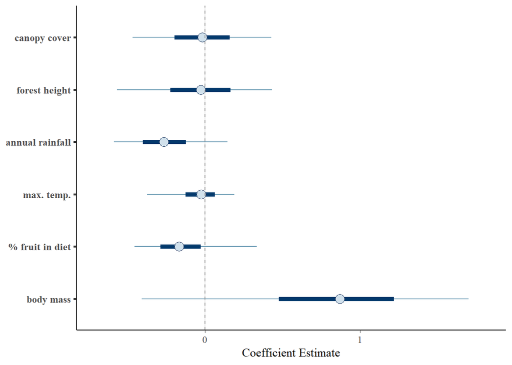

```r
#coefficient plot
mcmc_plot(brms3, pars = c("AvBody.mass.comb.sc", "Perc.fruit.comb.sc", "WC1_area_mean.sc",
                          "WC12_area_mean.sc", "FH.Median.sc", "TC.median.sc")) +
  geom_vline(xintercept = 0, linetype = "dashed", color = "grey60") +
  scale_y_discrete(labels = c("body mass", "% fruit in diet", "max. temp.", "annual rainfall",
                              "forest height", "canopy cover")) +
  xlab("Coefficient Estimate")
```

```r
#checking for multicollinearity
check_collinearity(brms3)
```

```
## # Check for Multicollinearity
##
## Low Correlation
##
##                 Term  VIF   VIF 95% CI Increased SE Tolerance Tolerance 95% CI
##    Estrada.Continent 1.12 [1.11, 1.15]         1.06      0.89     [0.87, 0.90]
##  AvBody.mass.comb.sc 1.54 [1.50, 1.57]         1.24      0.65     [0.64, 0.66]
##   Perc.fruit.comb.sc 1.51 [1.48, 1.55]         1.23      0.66     [0.65, 0.67]
##     WC1_area_mean.sc 2.00 [1.95, 2.05]         1.41      0.50     [0.49, 0.51]
##    WC12_area_mean.sc 2.19 [2.13, 2.24]         1.48      0.46     [0.45, 0.47]
##         FH.Median.sc 4.54 [4.41, 4.68]         2.13      0.22     [0.21, 0.23]
##         TC.median.sc 3.68 [3.57, 3.78]         1.92      0.27     [0.26, 0.28]
```

###Female body mass

Here I have ran the same model as above, but used female body mass instead of averaged body mass between males and females. The number of taxa included in the model decreases from 132 in the brms3 model above, to 112

```r
#running continuous model using female body mass instead of av body mass
brms3.1 <- brm(ground.use.prop ~
               Estrada.Continent +
               FBody.mass.comb.sc +                         # female body mass
               Perc.fruit.comb.sc +
               WC1_area_mean.sc +
               WC12_area_mean.sc +
               FH.Median.sc +
               TC.median.sc +
               (1|gr(TenK.tax, cov = A)),
             family = zero_inflated_beta(link = "logit"),
             data = primates,
             data2 = list(A = A),
             iter = 6000, warmup = 2000, thin = 1,
             prior = c(prior(normal(0,10), class = "Intercept"),
                       prior(normal(0,1), class = "b")),
             control = list(adapt_delta = 0.9999),
             cores = 10)
#model summary
summary(brms3.1)
```

```
##  Family: zero_inflated_beta
##   Links: mu = logit; phi = identity; zi = identity
## Formula: ground.use.prop ~ Estrada.Continent + FBody.mass.comb.sc + Perc.fruit.comb.sc + WC1_area_mean.sc + WC12_area_mean.sc + FH.Median.sc + TC.median.sc + (1 | gr(TenK.tax, cov = A))
##    Data: primates (Number of observations: 112)
##   Draws: 4 chains, each with iter = 6000; warmup = 2000; thin = 1;
##          total post-warmup draws = 16000
##
## Group-Level Effects:
## ~TenK.tax (Number of levels: 112)
##               Estimate Est.Error l-95% CI u-95% CI Rhat Bulk_ESS Tail_ESS
## sd(Intercept)     0.18      0.08     0.08     0.39 1.01      924      367
##
## Population-Level Effects:
##                             Estimate Est.Error l-95% CI u-95% CI Rhat Bulk_ESS
## Intercept                      -1.73      0.95    -3.79     0.03 1.00     6106
## Estrada.ContinentAsia          -0.08      0.48    -1.02     0.86 1.00     9217
## Estrada.ContinentMadagascar    -0.21      0.82    -1.79     1.42 1.00    13551
## Estrada.ContinentNeotropics    -0.40      0.79    -1.91     1.20 1.00    11721
## FBody.mass.comb.sc              1.20      0.52     0.19     2.22 1.00    10096
## Perc.fruit.comb.sc             -0.19      0.18    -0.52     0.17 1.00     3246
## WC1_area_mean.sc                0.02      0.13    -0.24     0.27 1.00     9103
## WC12_area_mean.sc              -0.51      0.22    -0.93    -0.08 1.00     9522
## FH.Median.sc                    0.14      0.30    -0.47     0.72 1.00     3536
## TC.median.sc                   -0.11      0.27    -0.62     0.42 1.00     7863
##                             Tail_ESS
## Intercept                       4214
## Estrada.ContinentAsia           8677
## Estrada.ContinentMadagascar    11242
## Estrada.ContinentNeotropics     8197
## FBody.mass.comb.sc             10170
## Perc.fruit.comb.sc              1754
## WC1_area_mean.sc                5577
## WC12_area_mean.sc              11124
## FH.Median.sc                    4725
## TC.median.sc                   10556
##
## Family Specific Parameters:
##     Estimate Est.Error l-95% CI u-95% CI Rhat Bulk_ESS Tail_ESS
## phi     6.46      5.73     3.07    17.28 1.00      945      361
## zi      0.29      0.04     0.21     0.38 1.00    26126    11831
##
## Draws were sampled using sampling(NUTS). For each parameter, Bulk_ESS
## and Tail_ESS are effective sample size measures, and Rhat is the potential
## scale reduction factor on split chains (at convergence, Rhat = 1).
```

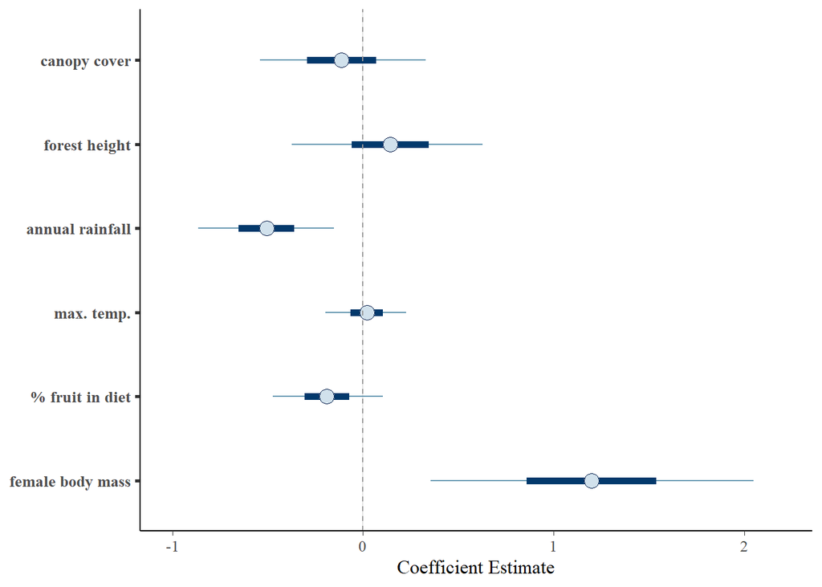

```r
#coefficient plot
mcmc_plot(brms3.1, pars = c("FBody.mass.comb.sc", "Perc.fruit.comb.sc", "WC1_area_mean.sc",
                          "WC12_area_mean.sc", "FH.Median.sc", "TC.median.sc")) +
  geom_vline(xintercept = 0, linetype = "dashed", color = "grey60") +
  scale_y_discrete(labels = c("female body mass", "% fruit in diet", "max. temp.", "annual rainfall",
                              "forest height", "canopy cover")) +
  xlab("Coefficient Estimate")
```

###Home range.

Adding home range as a predictor in the models. Home range and body mass are highly correlated, however:

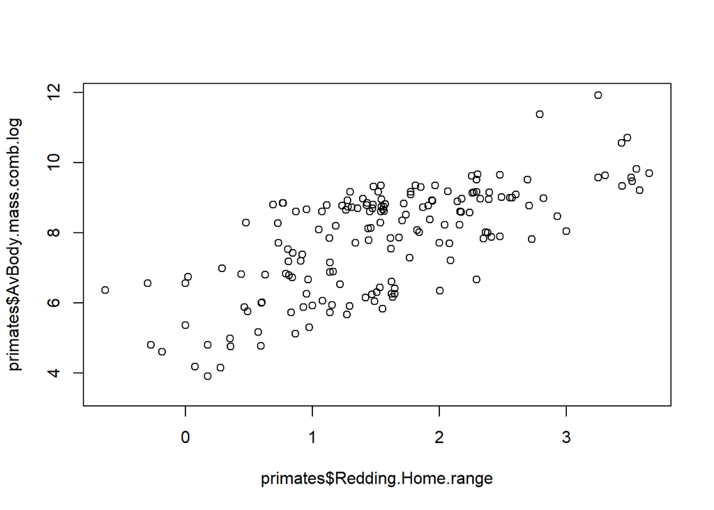

```r
plot(primates$AvBody.mass.comb.log ~ primates$Redding.Home.range)
```

```r
cor(primates$AvBody.mass.comb.log, primates$Redding.Home.range, method = "pearson", use = "complete.obs")
```

```
## [1] 0.6979416
```

Adding home range to the model anyway. Multiple error messages pop up. Rhat values are normal but ESS values are low, indicating less reliable coefficient estimates. Probably related to including two highly correlated variables - there doesn’t seem to be any issue with collinearity, however, according to the collinearity check. But looking at the coefficient plot, the estimates look odd. Not sure what to make of this, but moving forward without inlcuding home range for now.

```r
brms3.2 <- brm(ground.use.prop ~
                 Estrada.Continent +                           #continent
                 AvBody.mass.comb.sc +
                 Redding.Home.range +                         #body mass
                 Perc.fruit.comb.sc +                          #percent fruit in diet
                 WC1_area_mean.sc +                            #max temperature (mean across range)
                 WC12_area_mean.sc +                           #rainfall
                 FH.Median.sc +                                #forest height
                 TC.median.sc +                                #canopy cover percentage
               (1|gr(TenK.tax, cov = A)),
               family = zero_inflated_beta(link = "logit"),
               data = primates,
               data2 = list(A = A),
               iter = 6000, warmup = 2000, thin = 1,
               prior = c(prior(normal(0,10), class = "Intercept"),
                         prior(normal(0,1), class = "b")),
               control = list(adapt_delta = 0.9999),
               cores = 10)
#model summary
summary(brms3.2)
```

```
##  Family: zero_inflated_beta
##   Links: mu = logit; phi = identity; zi = identity
## Formula: ground.use.prop ~ Estrada.Continent + AvBody.mass.comb.sc + Redding.Home.range + Perc.fruit.comb.sc + WC1_area_mean.sc + WC12_area_mean.sc + FH.Median.sc + TC.median.sc + (1 | gr(TenK.tax, cov = A))
##    Data: primates (Number of observations: 87)
##   Draws: 4 chains, each with iter = 6000; warmup = 2000; thin = 1;
##          total post-warmup draws = 16000
##
## Group-Level Effects:
## ~TenK.tax (Number of levels: 87)
##               Estimate Est.Error l-95% CI u-95% CI Rhat Bulk_ESS Tail_ESS
## sd(Intercept)     0.39      0.11     0.17     0.56 1.03      165      618
##
## Population-Level Effects:
##                             Estimate Est.Error l-95% CI u-95% CI Rhat Bulk_ESS
## Intercept                      -3.24      1.79    -6.99     0.24 1.00     1565
## Estrada.ContinentAsia           0.45      0.67    -0.91     1.77 1.00     2629
## Estrada.ContinentMadagascar    -0.06      0.94    -1.91     1.79 1.00     5223
## Estrada.ContinentNeotropics    -0.27      0.93    -2.06     1.55 1.00     3899
## AvBody.mass.comb.sc             0.63      0.68    -0.75     1.92 1.00     1477
## Redding.Home.range              0.48      0.30    -0.11     1.08 1.00     2086
## Perc.fruit.comb.sc             -0.04      0.26    -0.56     0.49 1.00     2376
## WC1_area_mean.sc                0.19      0.18    -0.18     0.53 1.00     1847
## WC12_area_mean.sc              -1.12      0.27    -1.66    -0.59 1.00     1550
## FH.Median.sc                    0.34      0.35    -0.36     1.03 1.00     2359
## TC.median.sc                    0.02      0.32    -0.62     0.66 1.00     2212
##                             Tail_ESS
## Intercept                       2280
## Estrada.ContinentAsia           4976
## Estrada.ContinentMadagascar     7788
## Estrada.ContinentNeotropics     8614
## AvBody.mass.comb.sc             4219
## Redding.Home.range              3908
## Perc.fruit.comb.sc              3665
## WC1_area_mean.sc                3723
## WC12_area_mean.sc               3874
## FH.Median.sc                    3795
## TC.median.sc                    3784
##
## Family Specific Parameters:
##     Estimate Est.Error l-95% CI u-95% CI Rhat Bulk_ESS Tail_ESS
## phi   145.27    127.77     9.92   463.29 1.03      150      554
## zi      0.27      0.05     0.18     0.37 1.00     8986    10067
##
## Draws were sampled using sampling(NUTS). For each parameter, Bulk_ESS
## and Tail_ESS are effective sample size measures, and Rhat is the potential
## scale reduction factor on split chains (at convergence, Rhat = 1).
```

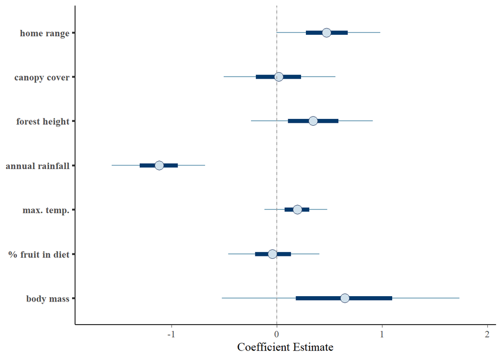

```r
#coefficient plot
mcmc_plot(brms3.2, pars = c("AvBody.mass.comb.sc", "Perc.fruit.comb.sc", "WC1_area_mean.sc",
                          "WC12_area_mean.sc", "FH.Median.sc", "TC.median.sc", "Redding.Home.range")) +
  geom_vline(xintercept = 0, linetype = "dashed", color = "grey60") +
  scale_y_discrete(labels = c("body mass", "% fruit in diet", "max. temp.", "annual rainfall",
                              "forest height", "canopy cover", "home range")) +
  xlab("Coefficient Estimate")
```

```r
#checking for multicollinearity
check_collinearity(brms3.2)
```

```
## # Check for Multicollinearity
##
## Low Correlation
##
##                 Term  VIF   VIF 95% CI Increased SE Tolerance Tolerance 95% CI
##    Estrada.Continent 1.09 [1.06, 1.14]         1.05      0.91     [0.88, 0.94]
##  AvBody.mass.comb.sc 1.31 [1.26, 1.37]         1.15      0.76     [0.73, 0.79]
##   Redding.Home.range 1.28 [1.23, 1.33]         1.13      0.78     [0.75, 0.81]
##   Perc.fruit.comb.sc 1.16 [1.12, 1.21]         1.08      0.86     [0.83, 0.89]
##     WC1_area_mean.sc 1.60 [1.53, 1.68]         1.27      0.62     [0.60, 0.65]
##    WC12_area_mean.sc 1.79 [1.70, 1.88]         1.34      0.56     [0.53, 0.59]
##         FH.Median.sc 3.59 [3.40, 3.81]         1.90      0.28     [0.26, 0.29]
##         TC.median.sc 3.09 [2.93, 3.27]         1.76      0.32     [0.31, 0.34]
```

###NDVI

Adding NDVI to the models. Running the model after simply adding NDVI resulted in a lot of errors. The collinearity check also showed high VIF values for NDVI and Canopy Cover. Running the model without canopy cover works just fine, though.

```r
brms3.3 <- brm(ground.use.prop ~
                 Estrada.Continent +                           #continent
                 AvBody.mass.comb.sc +                         #body mass
                 Perc.fruit.comb.sc +                          #percent fruit in diet
                 WC1_area_mean.sc +                            #max temperature (mean across range)
                 WC12_area_mean.sc +                           #rainfall
                 FH.Median.sc +                                #forest height
                 NDVI.MED.sc +                                 #median NDVI
                 (1|gr(TenK.tax, cov = A)),
               family = zero_inflated_beta(link = "logit"),
               data = primates,
               data2 = list(A = A),
               iter = 6000, warmup = 2000, thin = 1,
               prior = c(prior(normal(0,10), class = "Intercept"),
                         prior(normal(0,1), class = "b")),
               control = list(adapt_delta = 0.9999),
               cores = 10)
#model summary
summary(brms3.3)
```

```
##  Family: zero_inflated_beta
##   Links: mu = logit; phi = identity; zi = identity
## Formula: ground.use.prop ~ Estrada.Continent + AvBody.mass.comb.sc + Perc.fruit.comb.sc + WC1_area_mean.sc + WC12_area_mean.sc + FH.Median.sc + NDVI.MED.sc + (1 | gr(TenK.tax, cov = A))
##    Data: primates (Number of observations: 112)
##   Draws: 4 chains, each with iter = 6000; warmup = 2000; thin = 1;
##          total post-warmup draws = 16000
##
## Group-Level Effects:
## ~TenK.tax (Number of levels: 112)
##               Estimate Est.Error l-95% CI u-95% CI Rhat Bulk_ESS Tail_ESS
## sd(Intercept)     0.14      0.06     0.03     0.27 1.00     2274     3556
##
## Population-Level Effects:
##                             Estimate Est.Error l-95% CI u-95% CI Rhat Bulk_ESS
## Intercept                      -1.84      0.83    -3.66    -0.37 1.00     6132
## Estrada.ContinentAsia          -0.06      0.45    -0.97     0.82 1.00    11278
## Estrada.ContinentMadagascar    -0.25      0.78    -1.70     1.36 1.00    11785
## Estrada.ContinentNeotropics    -0.47      0.73    -1.84     1.04 1.00     9961
## AvBody.mass.comb.sc             0.75      0.50    -0.26     1.70 1.00    10289
## Perc.fruit.comb.sc             -0.21      0.17    -0.55     0.12 1.00    11215
## WC1_area_mean.sc                0.00      0.14    -0.28     0.27 1.00     9966
## WC12_area_mean.sc              -0.31      0.22    -0.73     0.11 1.00     9121
## FH.Median.sc                    0.08      0.20    -0.32     0.47 1.00     8268
## NDVI.MED.sc                    -0.11      0.15    -0.39     0.19 1.00    13538
##                             Tail_ESS
## Intercept                       6660
## Estrada.ContinentAsia          11022
## Estrada.ContinentMadagascar    11345
## Estrada.ContinentNeotropics    10672
## AvBody.mass.comb.sc            10641
## Perc.fruit.comb.sc             11565
## WC1_area_mean.sc               10472
## WC12_area_mean.sc               9978
## FH.Median.sc                    9908
## NDVI.MED.sc                    11496
##
## Family Specific Parameters:
##     Estimate Est.Error l-95% CI u-95% CI Rhat Bulk_ESS Tail_ESS
## phi     3.98      1.29     2.23     6.99 1.00     3191     4463
## zi      0.32      0.04     0.24     0.41 1.00    22406    11551
##
## Draws were sampled using sampling(NUTS). For each parameter, Bulk_ESS
## and Tail_ESS are effective sample size measures, and Rhat is the potential
## scale reduction factor on split chains (at convergence, Rhat = 1).
```

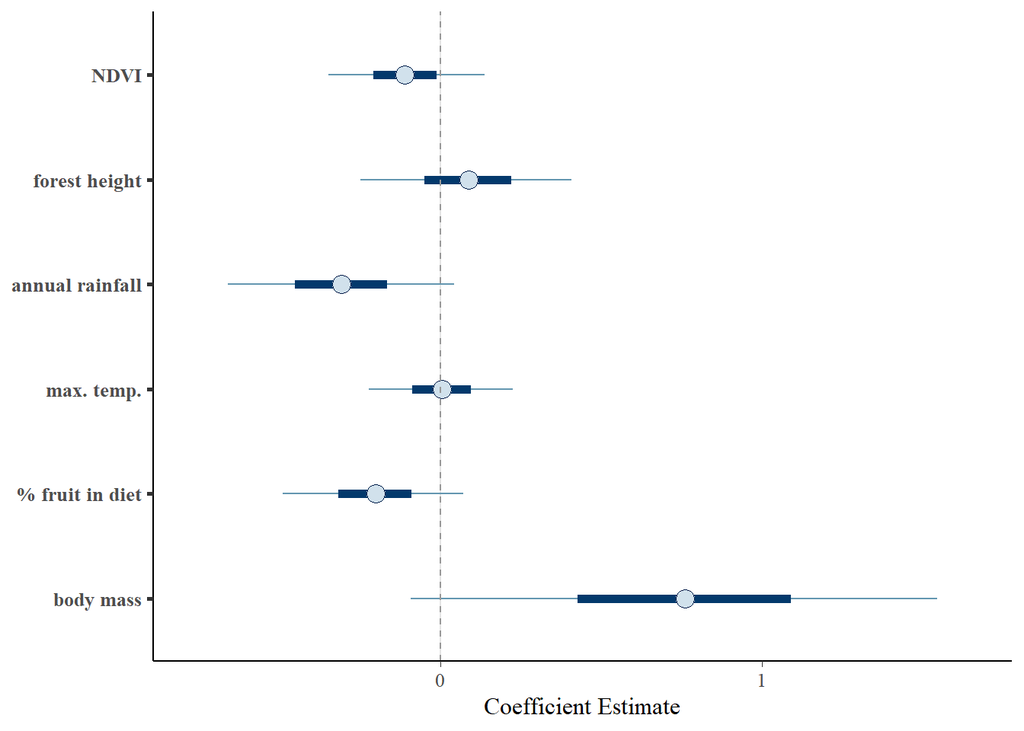

```r
#coefficient plot
mcmc_plot(brms3.3, pars = c("AvBody.mass.comb.sc", "Perc.fruit.comb.sc", "WC1_area_mean.sc",
                            "WC12_area_mean.sc", "FH.Median.sc","NDVI.MED.sc")) +
  geom_vline(xintercept = 0, linetype = "dashed", color = "grey60") +
  scale_y_discrete(labels = c("body mass", "% fruit in diet", "max. temp.", "annual rainfall",
                              "forest height", "NDVI")) +
  xlab("Coefficient Estimate")
```

```r
#checking for multicollinearity
check_collinearity(brms3.3)
```

```
## # Check for Multicollinearity
##
## Low Correlation
##
##                 Term  VIF   VIF 95% CI Increased SE Tolerance Tolerance 95% CI
##    Estrada.Continent 1.24 [1.21, 1.27]         1.11      0.81     [0.79, 0.83]
##  AvBody.mass.comb.sc 1.16 [1.14, 1.19]         1.08      0.86     [0.84, 0.88]
##   Perc.fruit.comb.sc 1.09 [1.07, 1.12]         1.05      0.92     [0.89, 0.93]
##     WC1_area_mean.sc 1.40 [1.36, 1.44]         1.18      0.71     [0.69, 0.73]
##    WC12_area_mean.sc 2.04 [1.98, 2.11]         1.43      0.49     [0.47, 0.50]
##         FH.Median.sc 1.94 [1.88, 2.00]         1.39      0.52     [0.50, 0.53]
##          NDVI.MED.sc 1.64 [1.60, 1.69]         1.28      0.61     [0.59, 0.63]
```

Running the brms3.3 model again but using female body mass

```r
brms3.4 <- brm(ground.use.prop ~
                 Estrada.Continent +                           #continent
                 FBody.mass.comb.sc +                          #female only body mass
                 Perc.fruit.comb.sc +                          #percent fruit in diet
                 WC1_area_mean.sc +                            #max temperature (mean across range)
                 WC12_area_mean.sc +                           #rainfall
                 FH.Median.sc +                                #forest height
                 NDVI.MED.sc +                                 #median NDVI
                 (1|gr(TenK.tax, cov = A)),
               family = zero_inflated_beta(link = "logit"),
               data = primates,
               data2 = list(A = A),
               iter = 6000, warmup = 2000, thin = 1,
               prior = c(prior(normal(0,10), class = "Intercept"),
                         prior(normal(0,1), class = "b")),
               control = list(adapt_delta = 0.9999),
               cores = 10)
#model summary - minor issues/warnings from the model above, probably because of smaller sample using female body mass only
summary(brms3.4)
```

```
##  Family: zero_inflated_beta
##   Links: mu = logit; phi = identity; zi = identity
## Formula: ground.use.prop ~ Estrada.Continent + FBody.mass.comb.sc + Perc.fruit.comb.sc + WC1_area_mean.sc + WC12_area_mean.sc + FH.Median.sc + NDVI.MED.sc + (1 | gr(TenK.tax, cov = A))
##    Data: primates (Number of observations: 93)
##   Draws: 4 chains, each with iter = 6000; warmup = 2000; thin = 1;
##          total post-warmup draws = 16000
##
## Group-Level Effects:
## ~TenK.tax (Number of levels: 93)
##               Estimate Est.Error l-95% CI u-95% CI Rhat Bulk_ESS Tail_ESS
## sd(Intercept)     0.15      0.07     0.03     0.30 1.00     1784     2498
##
## Population-Level Effects:
##                             Estimate Est.Error l-95% CI u-95% CI Rhat Bulk_ESS
## Intercept                      -1.71      0.84    -3.53    -0.17 1.00     6761
## Estrada.ContinentAsia           0.01      0.48    -0.93     0.98 1.00    13539
## Estrada.ContinentMadagascar    -0.25      0.79    -1.78     1.32 1.00    14470
## Estrada.ContinentNeotropics    -0.45      0.76    -1.89     1.13 1.00    13176
## FBody.mass.comb.sc              0.93      0.53    -0.13     1.98 1.00    14796
## Perc.fruit.comb.sc             -0.21      0.18    -0.57     0.15 1.00    14232
## WC1_area_mean.sc                0.04      0.14    -0.25     0.32 1.00    11912
## WC12_area_mean.sc              -0.55      0.25    -1.04    -0.07 1.00    10514
## FH.Median.sc                    0.14      0.23    -0.32     0.57 1.00     7830
## NDVI.MED.sc                    -0.09      0.16    -0.39     0.22 1.00    16326
##                             Tail_ESS
## Intercept                       6602
## Estrada.ContinentAsia          11531
## Estrada.ContinentMadagascar    12192
## Estrada.ContinentNeotropics    10456
## FBody.mass.comb.sc             12201
## Perc.fruit.comb.sc             12695
## WC1_area_mean.sc               10038
## WC12_area_mean.sc              12542
## FH.Median.sc                    9506
## NDVI.MED.sc                    10778
##
## Family Specific Parameters:
##     Estimate Est.Error l-95% CI u-95% CI Rhat Bulk_ESS Tail_ESS
## phi     4.39      1.87     2.33     8.38 1.00     2426     2819
## zi      0.31      0.05     0.22     0.40 1.00    28423    10897
##
## Draws were sampled using sampling(NUTS). For each parameter, Bulk_ESS
## and Tail_ESS are effective sample size measures, and Rhat is the potential
## scale reduction factor on split chains (at convergence, Rhat = 1).
```

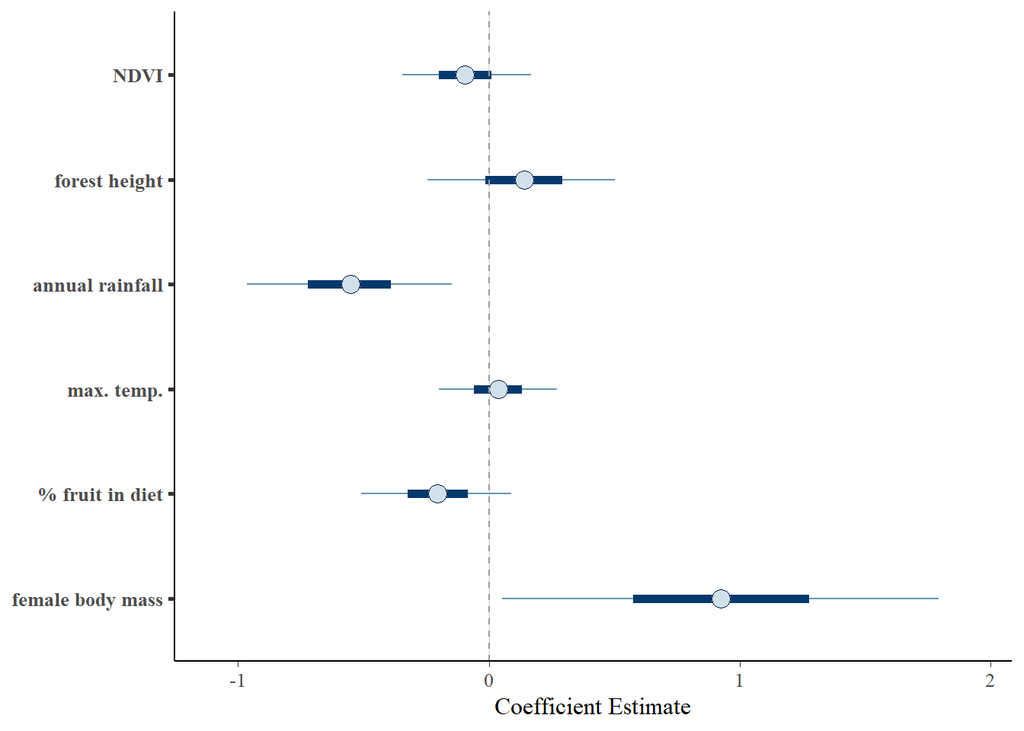

```r
#coefficient plot
mcmc_plot(brms3.4, pars = c("FBody.mass.comb.sc", "Perc.fruit.comb.sc", "WC1_area_mean.sc",
                            "WC12_area_mean.sc", "FH.Median.sc","NDVI.MED.sc")) +
  geom_vline(xintercept = 0, linetype = "dashed", color = "grey60") +
  scale_y_discrete(labels = c("female body mass", "% fruit in diet", "max. temp.", "annual rainfall",
                              "forest height", "NDVI")) +
  xlab("Coefficient Estimate")
```

```r
#checking for multicollinearity
check_collinearity(brms3.4)
```

```
## # Check for Multicollinearity
##
## Low Correlation
##
##                Term  VIF   VIF 95% CI Increased SE Tolerance Tolerance 95% CI
##   Estrada.Continent 1.29 [1.25, 1.34]         1.14      0.78     [0.75, 0.80]
##  FBody.mass.comb.sc 1.14 [1.11, 1.18]         1.07      0.88     [0.85, 0.90]
##  Perc.fruit.comb.sc 1.07 [1.04, 1.11]         1.03      0.94     [0.90, 0.96]
##    WC1_area_mean.sc 1.38 [1.33, 1.43]         1.17      0.72     [0.70, 0.75]
##   WC12_area_mean.sc 2.18 [2.09, 2.28]         1.48      0.46     [0.44, 0.48]
##        FH.Median.sc 2.12 [2.03, 2.21]         1.46      0.47     [0.45, 0.49]
##         NDVI.MED.sc 1.64 [1.58, 1.70]         1.28      0.61     [0.59, 0.63]
```

### Predation Pressure

Following Eppley et al. (2022), I created a metric of predation pressure - an integer value representing the number of terrestrial carnivores whose ranges overlap with the focal primate AND with a body mass that is at least 25% of the focal primate’s mass. Carnivore range data from the IUCN, terrestriality data from the PanTHERIA database, and body mass data from the Animal Diversity Web and PanTHERIA databases.

Running the model first with avg body mass

```r
brms3.5 <- brm(ground.use.prop ~
                 Estrada.Continent +                           #continent
                 AvBody.mass.comb.sc +                         #body mass
                 Perc.fruit.comb.sc +                          #percent fruit in diet
                 WC1_area_mean.sc +                            #max temperature (mean across range)
                 WC12_area_mean.sc +                           #rainfall
                 FH.Median.sc +                                #forest height
                 NDVI.MED.sc +                                 #median NDVI
                 n.carn.sc +                                   #number of carnivores (predation pressure proxy)
                 (1|gr(TenK.tax, cov = A)),
               family = zero_inflated_beta(link = "logit"),
               data = primates,
               data2 = list(A = A),
               iter = 6000, warmup = 2000, thin = 1,
               prior = c(prior(normal(0,10), class = "Intercept"),
                         prior(normal(0,1), class = "b")),
               control = list(adapt_delta = 0.9999),
               cores = 10)
#model summary
summary(brms3.5)
```

```
##  Family: zero_inflated_beta
##   Links: mu = logit; phi = identity; zi = identity
## Formula: ground.use.prop ~ Estrada.Continent + AvBody.mass.comb.sc + Perc.fruit.comb.sc + WC1_area_mean.sc + WC12_area_mean.sc + FH.Median.sc + NDVI.MED.sc + n.carn.sc + (1 | gr(TenK.tax, cov = A))
##    Data: primates (Number of observations: 103)
##   Draws: 4 chains, each with iter = 6000; warmup = 2000; thin = 1;
##          total post-warmup draws = 16000
##
## Group-Level Effects:
## ~TenK.tax (Number of levels: 103)
##               Estimate Est.Error l-95% CI u-95% CI Rhat Bulk_ESS Tail_ESS
## sd(Intercept)     0.13      0.06     0.02     0.27 1.00     2348     3697
##
## Population-Level Effects:
##                             Estimate Est.Error l-95% CI u-95% CI Rhat Bulk_ESS
## Intercept                      -1.75      0.79    -3.48    -0.30 1.00     8319
## Estrada.ContinentAsia          -0.07      0.46    -0.99     0.83 1.00    12934
## Estrada.ContinentMadagascar    -0.15      0.76    -1.64     1.38 1.00    14490
## Estrada.ContinentNeotropics    -0.47      0.71    -1.86     0.97 1.00    13290
## AvBody.mass.comb.sc             0.86      0.51    -0.17     1.83 1.00    11450
## Perc.fruit.comb.sc             -0.22      0.17    -0.56     0.12 1.00    13437
## WC1_area_mean.sc                0.03      0.15    -0.26     0.31 1.00    11885
## WC12_area_mean.sc              -0.29      0.22    -0.72     0.15 1.00    11507
## FH.Median.sc                    0.13      0.22    -0.31     0.54 1.00     8058
## NDVI.MED.sc                    -0.15      0.16    -0.45     0.17 1.00    14677
## n.carn.sc                       0.09      0.15    -0.22     0.39 1.00    10518
##                             Tail_ESS
## Intercept                       7514
## Estrada.ContinentAsia          11010
## Estrada.ContinentMadagascar    11612
## Estrada.ContinentNeotropics    11451
## AvBody.mass.comb.sc            10500
## Perc.fruit.comb.sc             13008
## WC1_area_mean.sc               11343
## WC12_area_mean.sc              11232
## FH.Median.sc                   10384
## NDVI.MED.sc                    12246
## n.carn.sc                      11033
##
## Family Specific Parameters:
##     Estimate Est.Error l-95% CI u-95% CI Rhat Bulk_ESS Tail_ESS
## phi     3.69      1.14     2.12     6.38 1.00     3818     4877
## zi      0.30      0.04     0.22     0.40 1.00    25410    11456
##
## Draws were sampled using sampling(NUTS). For each parameter, Bulk_ESS
## and Tail_ESS are effective sample size measures, and Rhat is the potential
## scale reduction factor on split chains (at convergence, Rhat = 1).
```

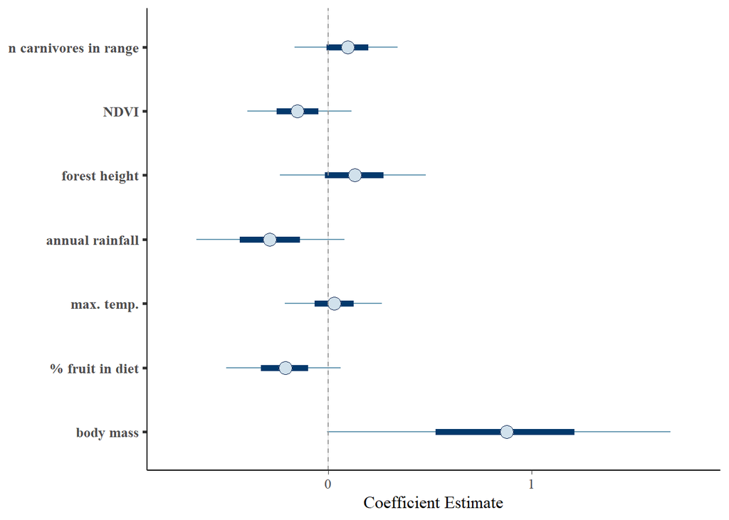

```r
#coefficient plot
mcmc_plot(brms3.5, pars = c("AvBody.mass.comb.sc", "Perc.fruit.comb.sc", "WC1_area_mean.sc",
                            "WC12_area_mean.sc", "FH.Median.sc","NDVI.MED.sc", "n.carn.sc")) +
  geom_vline(xintercept = 0, linetype = "dashed", color = "grey60") +
  scale_y_discrete(labels = c("body mass", "% fruit in diet", "max. temp.", "annual rainfall",
                              "forest height", "NDVI", "n carnivores in range")) +
  xlab("Coefficient Estimate")
```

```r
#checking for multicollinearity
check_collinearity(brms3.5)
```

```
## # Check for Multicollinearity
##
## Low Correlation
##
##                 Term  VIF   VIF 95% CI Increased SE Tolerance Tolerance 95% CI
##    Estrada.Continent 1.31 [1.27, 1.36]         1.14      0.76     [0.74, 0.79]
##  AvBody.mass.comb.sc 1.27 [1.23, 1.31]         1.13      0.79     [0.76, 0.81]
##   Perc.fruit.comb.sc 1.11 [1.08, 1.15]         1.05      0.90     [0.87, 0.92]
##     WC1_area_mean.sc 1.42 [1.37, 1.47]         1.19      0.71     [0.68, 0.73]
##    WC12_area_mean.sc 2.07 [1.99, 2.15]         1.44      0.48     [0.46, 0.50]
##         FH.Median.sc 2.18 [2.09, 2.27]         1.48      0.46     [0.44, 0.48]
##          NDVI.MED.sc 1.73 [1.66, 1.79]         1.31      0.58     [0.56, 0.60]
##            n.carn.sc 1.41 [1.36, 1.46]         1.19      0.71     [0.69, 0.73]
```

Running again with female body mass instead of avg body mass

```r
brms3.6 <- brm(ground.use.prop ~
                 Estrada.Continent +                           #continent
                 FBody.mass.comb.sc +                          #female only body mass
                 Perc.fruit.comb.sc +                          #percent fruit in diet
                 WC1_area_mean.sc +                            #max temperature (mean across range)
                 WC12_area_mean.sc +                           #rainfall
                 FH.Median.sc +                                #forest height
                 NDVI.MED.sc +                                 #median NDVI
                 n.carn.sc +                                   #number of carnivores (predation pressure proxy)
                 (1|gr(TenK.tax, cov = A)),
               family = zero_inflated_beta(link = "logit"),
               data = primates,
               data2 = list(A = A),
               iter = 6000, warmup = 2000, thin = 1,
               prior = c(prior(normal(0,10), class = "Intercept"),
                         prior(normal(0,1), class = "b")),
               control = list(adapt_delta = 0.9999),
               cores = 10)
#model summary - minor issues/warnings probably because of smaller sample using female body mass only
summary(brms3.6)
```

```
##  Family: zero_inflated_beta
##   Links: mu = logit; phi = identity; zi = identity
## Formula: ground.use.prop ~ Estrada.Continent + FBody.mass.comb.sc + Perc.fruit.comb.sc + WC1_area_mean.sc + WC12_area_mean.sc + FH.Median.sc + NDVI.MED.sc + n.carn.sc + (1 | gr(TenK.tax, cov = A))
##    Data: primates (Number of observations: 90)
##   Draws: 4 chains, each with iter = 6000; warmup = 2000; thin = 1;
##          total post-warmup draws = 16000
##
## Group-Level Effects:
## ~TenK.tax (Number of levels: 90)
##               Estimate Est.Error l-95% CI u-95% CI Rhat Bulk_ESS Tail_ESS
## sd(Intercept)     0.14      0.07     0.02     0.30 1.00     1643     1521
##
## Population-Level Effects:
##                             Estimate Est.Error l-95% CI u-95% CI Rhat Bulk_ESS
## Intercept                      -1.63      0.85    -3.52    -0.02 1.00     7895
## Estrada.ContinentAsia          -0.06      0.49    -1.02     0.90 1.00    13922
## Estrada.ContinentMadagascar    -0.18      0.79    -1.70     1.40 1.00    16106
## Estrada.ContinentNeotropics    -0.44      0.74    -1.83     1.11 1.00    12614
## FBody.mass.comb.sc              1.01      0.54    -0.06     2.05 1.00    17180
## Perc.fruit.comb.sc             -0.22      0.18    -0.58     0.13 1.00    12642
## WC1_area_mean.sc                0.04      0.15    -0.25     0.32 1.00    14181
## WC12_area_mean.sc              -0.52      0.26    -1.02    -0.02 1.00    11380
## FH.Median.sc                    0.18      0.24    -0.29     0.64 1.00     6108
## NDVI.MED.sc                    -0.13      0.16    -0.44     0.20 1.00    13453
## n.carn.sc                       0.12      0.16    -0.19     0.42 1.00    13631
##                             Tail_ESS
## Intercept                       6157
## Estrada.ContinentAsia          10765
## Estrada.ContinentMadagascar    11097
## Estrada.ContinentNeotropics     8254
## FBody.mass.comb.sc             12349
## Perc.fruit.comb.sc              8414
## WC1_area_mean.sc               11894
## WC12_area_mean.sc              10578
## FH.Median.sc                    8292
## NDVI.MED.sc                    11340
## n.carn.sc                      11887
##
## Family Specific Parameters:
##     Estimate Est.Error l-95% CI u-95% CI Rhat Bulk_ESS Tail_ESS
## phi     4.33      3.01     2.26     8.34 1.00     2194     1664
## zi      0.29      0.05     0.20     0.39 1.00    31639    11232
##
## Draws were sampled using sampling(NUTS). For each parameter, Bulk_ESS
## and Tail_ESS are effective sample size measures, and Rhat is the potential
## scale reduction factor on split chains (at convergence, Rhat = 1).
```

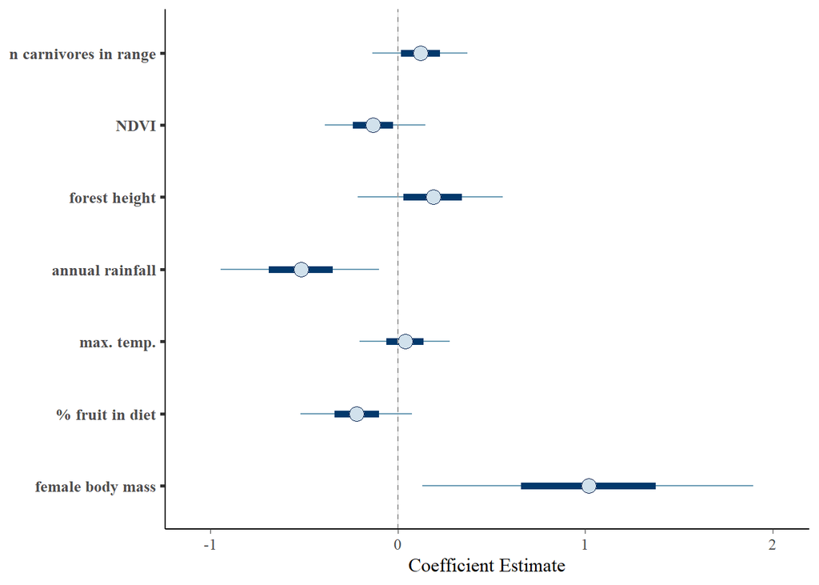

```r
#coefficient plot - same pattern here as when I ran the original brms3 model with female body mass instead of avg body mass - rainfall is more of a reliable predictor and so are other vars, but many still overlap with zero
mcmc_plot(brms3.6, pars = c("FBody.mass.comb.sc", "Perc.fruit.comb.sc", "WC1_area_mean.sc",
                            "WC12_area_mean.sc", "FH.Median.sc","NDVI.MED.sc", "n.carn.sc")) +
  geom_vline(xintercept = 0, linetype = "dashed", color = "grey60") +
  scale_y_discrete(labels = c("female body mass", "% fruit in diet", "max. temp.", "annual rainfall",
                              "forest height", "NDVI", "n carnivores in range")) +
  xlab("Coefficient Estimate")
```

```r
#checking for multicollinearity - no issues here
check_collinearity(brms3.6)
```

```
## # Check for Multicollinearity
##
## Low Correlation
##
##                Term  VIF   VIF 95% CI Increased SE Tolerance Tolerance 95% CI
##   Estrada.Continent 1.43 [1.38, 1.49]         1.20      0.70     [0.67, 0.73]
##  FBody.mass.comb.sc 1.20 [1.16, 1.25]         1.09      0.83     [0.80, 0.86]
##  Perc.fruit.comb.sc 1.09 [1.06, 1.13]         1.04      0.92     [0.88, 0.95]
##    WC1_area_mean.sc 1.42 [1.36, 1.48]         1.19      0.71     [0.68, 0.73]
##   WC12_area_mean.sc 2.23 [2.13, 2.35]         1.49      0.45     [0.43, 0.47]
##        FH.Median.sc 2.18 [2.08, 2.29]         1.48      0.46     [0.44, 0.48]
##         NDVI.MED.sc 1.74 [1.67, 1.82]         1.32      0.57     [0.55, 0.60]
##           n.carn.sc 1.29 [1.25, 1.35]         1.14      0.77     [0.74, 0.80]
```

##Ancestral State Reconstruction This is still in a work in progress, but so far I’ve been able to visualize the ACR using the {phytools} package

Some prep work first to create a vector that {phytools} can use

```r
#reading in an excel file that I used to align the two different taxonomies used for 10kTrees and IUCN
taxa <- read.csv(file = "10k_primate_tree_taxa.xls.csv", header = TRUE)
colnames(taxa) <- c("X10k_tax", "scientific_name", "remove")
#adding terrestriality data from my 'primates' data set
taxa <- left_join(taxa, primates[,c("scientific_name", "Terrestrial.binary", "Terrestrial.ordinal")], by = "scientific_name")

#reading in the binary tree from 10kTrees
binary_tree <- read.nexus(file = "10kTrees_Primates_binary.nex")

#fixing the Latin binomials first (had to run twice to remove the underscore preceding the subspecies name as well)
binary_tree$tip.label <- sub("_"," ", binary_tree$tip.label)
binary_tree$tip.label <- sub("_"," ", binary_tree$tip.label)

#creating binary terrestriality data frame in structure used by ggtree heat map
terr_bin_data <- data.frame(taxa[taxa$X10k_tax %in% binary_tree$tip.label, 4])
rownames(terr_bin_data) <- taxa[taxa$X10k_tax %in% binary_tree$tip.label, 1]

terr_bin_data <- setNames(terr_bin_data$taxa.taxa.X10k_tax..in..binary_tree.tip.label..4., rownames(terr_bin_data))
```

I can run some different Ancestral State Reconstruction functions, which take different approaches. It would seem the Bayesian approach would be best, since I’m using Bayesian models above for this data. the fastAnc() function uses Fesenstein’s contrasts algorith (1985) while the anc.Bayes() function uses MCMC to estimate states for all internal nodes of the primate phylogenetic tree

```r
anc_result <- fastAnc(binary_tree, terr_bin_data)
anc_result
```

[output not shown]

[output cut: 14 more lines]

[output not shown]

```r
Bayes_result <- anc.Bayes(binary_tree, terr_bin_data)
```

```
## Control parameters (set by user or default):
```

```
## List of 7
##  $ sig2   : num 0.00897
##  $ a      : num [1, 1] 0.0427
##  $ y      : num [1:271] 0.0427 0.0427 0.0427 0.0427 0.0427 ...
##  $ pr.mean: num [1:273] 1000 0 0 0 0 0 0 0 0 0 ...
##  $ pr.var : num [1:273] 1e+06 1e+03 1e+03 1e+03 1e+03 1e+03 1e+03 1e+03 1e+03 1e+03 ...
##  $ prop   : num [1:273] 0.00655 0.00655 0.00655 0.00655 0.00655 ...
##  $ sample : num 100
```

```
## Starting MCMC...
```

```
## Done MCMC.
```

```r
Bayes_result
```

[output not shown]

[output cut: 20 more lines]

[output not shown]

visualizing ACR - the visualization process seems completely separate from the ACR process above, and I’m not sure why. Here I am able to visualize a tree for the binary terrestriality data, inserting points at the nodes where character transitions occur. The ancestral state estimation is done using MCMC

```r
#ancestral state estimation
simmap_bin <- make.simmap(binary_tree, terr_bin_data, Q = "mcmc")
```

```
## Running MCMC burn-in. Please wait....
## Running 100 generations of MCMC, sampling every 100 generations.
## Please wait....
##
## make.simmap is simulating with a sample of Q from
## the posterior distribution
##
## Mean Q from the posterior is
## Q =
##              FALSE         TRUE
## FALSE -0.006367248  0.006367248
## TRUE   0.006367248 -0.006367248
## and (mean) root node prior probabilities
## pi =
## FALSE  TRUE
##   0.5   0.5
```

```
## Done.
```

```r
#plotting
plotSimmap(simmap_bin,
           lwd = 2,
           outline = FALSE,
           fsize = 0.3,
           ftype="i",
           ylim = c(-1,Ntip(binary_tree)))
```

```
## no colors provided. using the following legend:
##     FALSE      TRUE
##   "black" "#DF536B"
```

[figure not shown]

```r
add.simmap.legend(colors = c("black", "#DF536B"), prompt = FALSE)  #legend text doesn't show up. not sure how to add it
chg <- markChanges(simmap_bin,  plot = FALSE)
points(chg, pch = 16)
```